# Homework 2

Kyle Bowman

12 February, 2019

## Problem #1

```r
format(Sys.time(), '%d %B, %Y')
```

```
## [1] "12 February, 2019"
```

## Problem #2

### (a):

```r
ice_cream <- read.csv("C:/Users/kjbow/Desktop/School/CMDA 2005/Stats/Homework/Homework 2/ice_cream.csv")

ice_cream[,"Income"]
```

```
##  [1] 78 79 81 80 76 78 82 79 76 79 82 85 86 83 84 82 80 78 84 86 85 87 94
## [24] 92 95 96 94 96 91 90
```

```r
ice_cream$Income
```

```
##  [1] 78 79 81 80 76 78 82 79 76 79 82 85 86 83 84 82 80 78 84 86 85 87 94
## [24] 92 95 96 94 96 91 90
```

### (b):

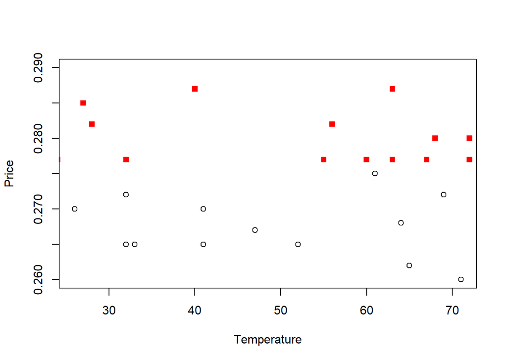

```r
lowerRows = ice_cream$Price <= 0.275
higherRows = ice_cream$Price > 0.275
plot(ice_cream[lowerRows, "Temp"], ice_cream[lowerRows, "Price"], ylim = c(0.26, 0.29), ylab = "Price", xlab = "Temperature")
points(ice_cream[higherRows, "Temp"], ice_cream[higherRows, "Price"], pch = 15, col="red")
```

The relationship of price vs temperature is non-linear

### (c):

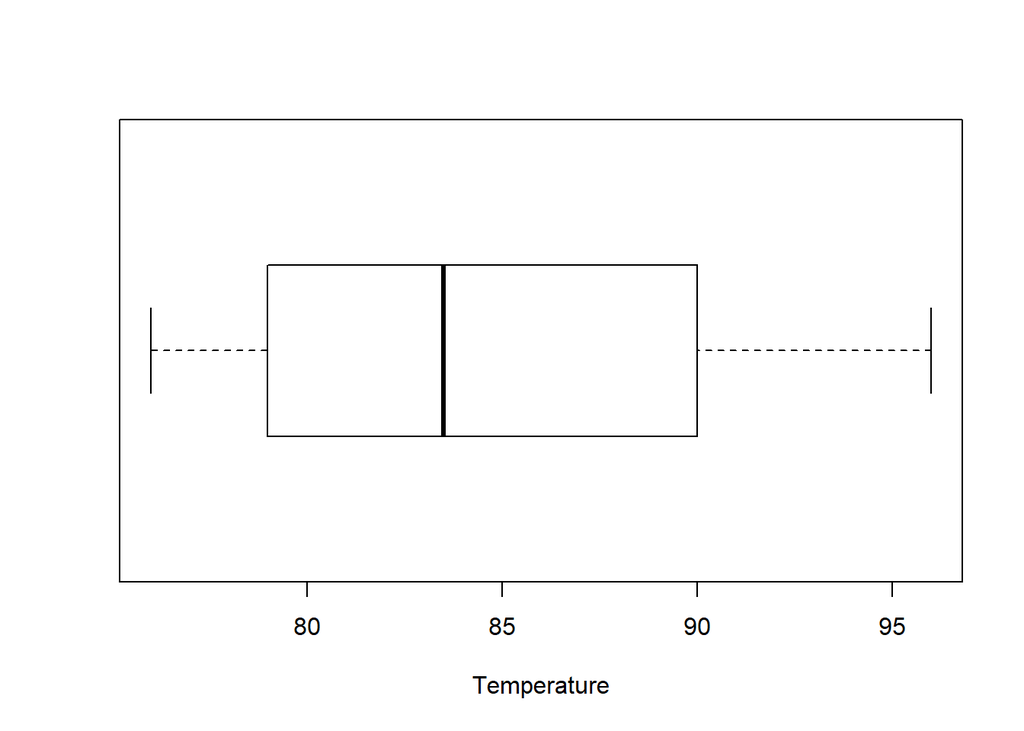

```r
boxplot(ice_cream$Income, horizontal = TRUE, xlab = "Temperature")
```

The box plot is much smaller on the left side, meaning the left portion of the data is closer together, which would make the graph skewed to the right.

### (d):

```r
prices <- ice_cream$Price
prices <- prices[ice_cream$Temp >= 50 & ice_cream$Temp <= 65]
mean(prices)
```

```
## [1] 0.2744444
```

```r
sd(prices)
```

```
## [1] 0.00806398
```

### (e):

```r
prices <- ice_cream$Price
prices <- prices[ice_cream$Temp < 50 || ice_cream$Temp > 65]
mean(prices)
```

```
## [1] 0.2753
```

```r
quantile(prices, c(0.1, 0.25, 0.78, 0.9))
```

```
##    10%    25%    78%    90%
## 0.2650 0.2685 0.2820 0.2870
```

## Problem #3

### (a):

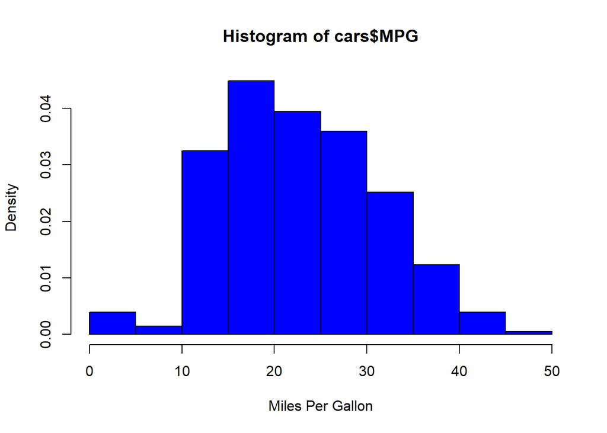

```r
cars <- read.csv("C:/Users/kjbow/Desktop/School/CMDA 2005/Stats/Homework/Homework 2/cars.csv")
hist(cars$MPG, breaks= 12, freq = FALSE, col= "blue", xlab="Miles Per Gallon")
```

### (b):

```r
cylinders <- factor(cars$Cylinders)
print("Cylinder Type: Average MPG")
```

```
## [1] "Cylinder Type: Average MPG"
```

```r
for (level in levels(cylinders)) {
 print(paste(level, mean(cars$MPG[cylinders == level]), sep=": "))
}
```

```
## [1] "3: 20.55"
## [1] "4: 28.8623188405797"
## [1] "5: 27.3666666666667"
## [1] "6: 19.9857142857143"
## [1] "8: 14.2703703703704"
```

### (c):

```r
countries <- factor(cars$Origin)
for (level in levels(countries)) {
 print(paste(level, mean(cars$Weight[countries == level]), sep=": "))
}
```

```
## [1] "Europe: 2431.49315068493"
## [1] "Japan: 2221.22784810127"
## [1] "US: 3372.70078740157"
```

### (d):

```r
print("United States Horsepower Summary:")
```

```
## [1] "United States Horsepower Summary:"
```

```r
summary(cars$Horsepower[countries == "US"])
```

```
##    Min. 1st Qu.  Median    Mean 3rd Qu.    Max.
##       0      88     105     118     150     230
```

```r
print("Europe Horsepower Summary:")
```

```
## [1] "Europe Horsepower Summary:"
```

```r
summary(cars$Horsepower[countries == "Europe"])
```

```
##    Min. 1st Qu.  Median    Mean 3rd Qu.    Max.
##    0.00   69.00   76.00   78.78   90.00  133.00
```

```r
print("Japan Horsepower Summary:")
```

```
## [1] "Japan Horsepower Summary:"
```

```r
summary(cars$Horsepower[countries == "Japan"])
```

```
##    Min. 1st Qu.  Median    Mean 3rd Qu.    Max.
##   52.00   67.00   75.00   79.84   95.00  132.00
```

### (e):

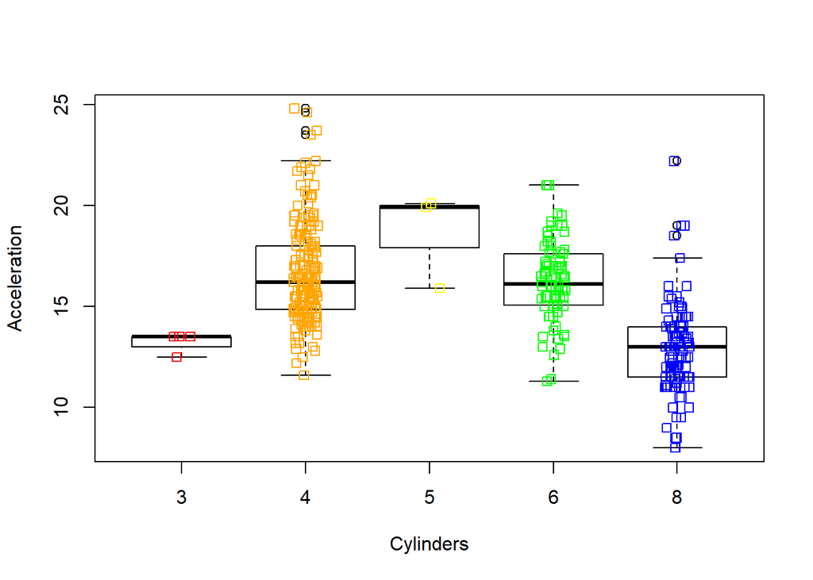

```r
boxplot(cars$Acceleration[cylinders == "3"],
        cars$Acceleration[cylinders == "4"],
        cars$Acceleration[cylinders == "5"],
        cars$Acceleration[cylinders == "6"],
        cars$Acceleration[cylinders == "8"],
        names = levels(cylinders), xlab="Cylinders", ylab="Acceleration")

stripchart(cars$Acceleration[(cylinders) == "3"], add = TRUE, method="jitter", at= 1, vertical = TRUE, col="red")
stripchart(cars$Acceleration[(cylinders) == "4"], add = TRUE, method="jitter", at= 2, vertical = TRUE, col="orange")
stripchart(cars$Acceleration[(cylinders) == "5"], add = TRUE, method="jitter", at = 3, vertical = TRUE, col="yellow")
stripchart(cars$Acceleration[(cylinders) == "6"], add = TRUE, method="jitter", at = 4, vertical = TRUE, col="green")
stripchart(cars$Acceleration[(cylinders) == "8"], add = TRUE, method="jitter", at = 5, vertical = TRUE, col="blue")
```

The five cylinder engines offer the highest median acceleration. The four and eight cylinder engines have the highest variability of all the engines

### (f):

```r
table(cylinders, countries)
```

```
##          countries
## cylinders Europe Japan  US
##         3      0     4   0
##         4     66    69  72
##         5      3     0   0
##         6      4     6  74
##         8      0     0 108
```

### (g):

```r
c1 <- c(length(cars$Cylinders[countries == "Europe" & cylinders == "3"]),
        length(cars$Cylinders[countries == "Europe" & cylinders == "4"]),
        length(cars$Cylinders[countries == "Europe" & cylinders == "5"]),
        length(cars$Cylinders[countries == "Europe" & cylinders == "6"]),
        length(cars$Cylinders[countries == "Europe" & cylinders == "8"]))
c2 <- c(length(cars$Cylinders[countries == "Japan" & cylinders == "3"]),
        length(cars$Cylinders[countries == "Japan" & cylinders == "4"]),
        length(cars$Cylinders[countries == "Japan" & cylinders == "5"]),
        length(cars$Cylinders[countries == "Japan" & cylinders == "6"]),
        length(cars$Cylinders[countries == "Japan" & cylinders == "8"]))
c3 <- c(length(cars$Cylinders[countries == "US" & cylinders == "3"]),
        length(cars$Cylinders[countries == "US" & cylinders == "4"]),
        length(cars$Cylinders[countries == "US" & cylinders == "5"]),
        length(cars$Cylinders[countries == "US" & cylinders == "6"]),
        length(cars$Cylinders[countries == "US" & cylinders == "8"]))
frequencies <- matrix(c(c1/sum(c1), c2/sum(c2), c3/sum(c3)), ncol = 3)
frequencies
```

```
##            [,1]       [,2]      [,3]
## [1,] 0.00000000 0.05063291 0.0000000
## [2,] 0.90410959 0.87341772 0.2834646
## [3,] 0.04109589 0.00000000 0.0000000
## [4,] 0.05479452 0.07594937 0.2913386
## [5,] 0.00000000 0.00000000 0.4251969
```

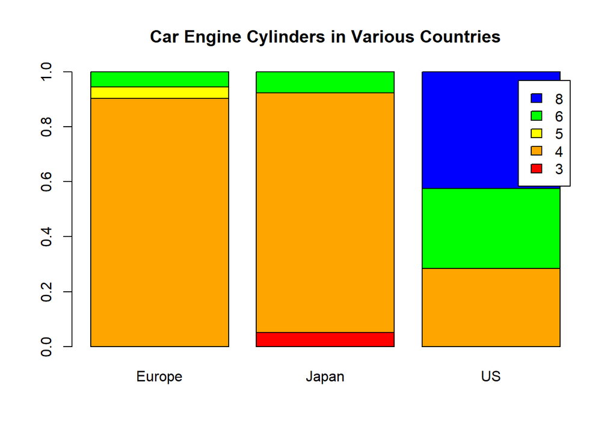

```r
barplot(frequencies, names.arg=levels(countries), legend.text=levels(cylinders), main="Car Engine Cylinders in Various Countries", col=c("red","orange","yellow","green","blue"))
```

### (h):

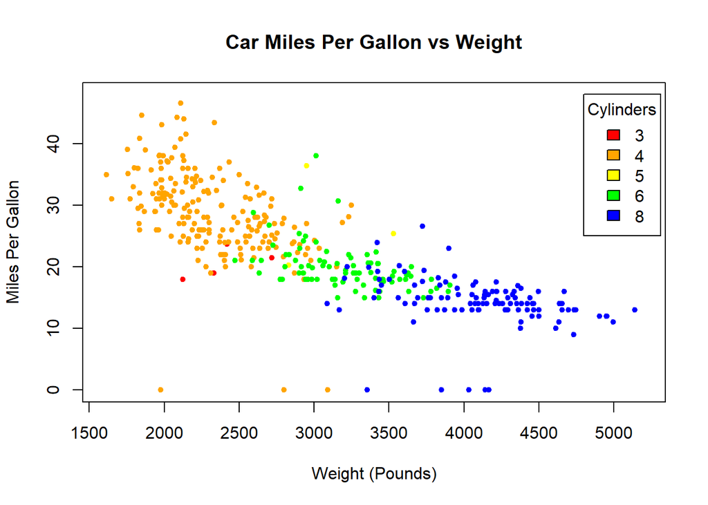

```r
plot(cars$Weight[cylinders == 3], cars$MPG[cylinders == 3], pch = 20, col = "red", xlim=c(1600, 5200), ylim=c(0, 48), main="Car Miles Per Gallon vs Weight", xlab="Weight (Pounds)", ylab="Miles Per Gallon")
points(cars$Weight[cylinders == 4], cars$MPG[cylinders == 4], pch = 20, col = "orange")
points(cars$Weight[cylinders == 5], cars$MPG[cylinders == 5], pch = 20, col = "yellow")
points(cars$Weight[cylinders == 6], cars$MPG[cylinders == 6], pch = 20, col = "green")
points(cars$Weight[cylinders == 8], cars$MPG[cylinders == 8], pch = 20, col = "blue")
legend(4800, 48, fill=c("red", "orange", "yellow", "green", "blue"), legend=c(3,4,5,6,8), title="Cylinders")
```

I chose to remove the bottom points because the MPG can’t be zero for a car, so an error must have occurred

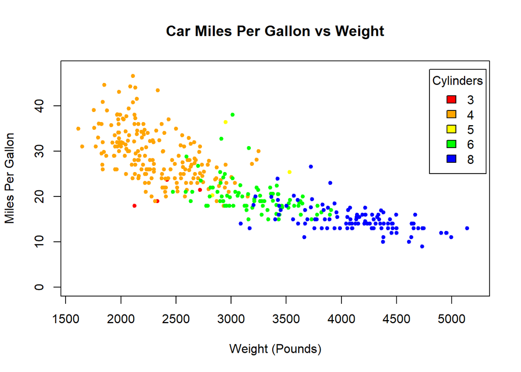

```r
plot(cars$Weight[cylinders == 3 & cars$MPG!=0], cars$MPG[cylinders == 3 & cars$MPG!=0], pch = 20, col = "red", xlim=c(1600, 5200), ylim=c(0, 48), main="Car Miles Per Gallon vs Weight", xlab="Weight (Pounds)", ylab="Miles Per Gallon")
points(cars$Weight[cylinders == 4 & cars$MPG!=0], cars$MPG[cylinders == 4 & cars$MPG!=0], pch = 20, col = "orange")
points(cars$Weight[cylinders == 5 & cars$MPG!=0], cars$MPG[cylinders == 5 & cars$MPG!=0], pch = 20, col = "yellow")
points(cars$Weight[cylinders == 6 & cars$MPG!=0], cars$MPG[cylinders == 6 & cars$MPG!=0], pch = 20, col = "green")
points(cars$Weight[cylinders == 8 & cars$MPG!=0], cars$MPG[cylinders == 8 & cars$MPG!=0], pch = 20, col = "blue")
legend(4800, 48, fill=c("red", "orange", "yellow", "green", "blue"), legend=c(3,4,5,6,8), title="Cylinders")
```

## Problem #4

### (a):

```r
library(MASS)
?UScereal
```

```
## starting httpd help server ... done
```

The categorical variables in this dataset are: manufacturer, shelf, vitamins

### (b):

```r
table(UScereal$mfr)
```

```
##
##  G  K  N  P  Q  R
## 22 21  3  9  5  5
```

### (c):

```r
cal <- UScereal$calories
c1 <- which.max(cal)
cal[c1] = -1
c2 <- which.max(cal)
cal[c2] = -1
c3 <- which.max(cal)
cal[c3] = -1
c4 <- which.max(cal)
cal[c4] = -1
c5 <- which.max(cal)
highest <- c(c1,c2,c3,c4,c5)

cal <- UScereal$calories
c1 <- which.min(cal)
cal[c1] = 10000
c2 <- which.min(cal)
cal[c2] = 10000
c3 <- which.min(cal)
cal[c3] = 10000
c4 <- which.min(cal)
cal[c4] = 10000
c5 <- which.min(cal)
lowest <- c(c1,c2,c3,c4,c5)

cereals <- row.names(UScereal)
print("Highest calorie cereals: ")
```

```
## [1] "Highest calorie cereals: "
```

```r
cereals[highest]
```

```
## [1] "Grape-Nuts"           "Great Grains Pecan"   "Oatmeal Raisin Crisp"
## [4] "Mueslix Crispy Blend" "Clusters"
```

```r
print("Lowest calorie cereals: ")
```

```
## [1] "Lowest calorie cereals: "
```

```r
cereals[lowest]
```

```
## [1] "Puffed Rice" "Kix"         "Honey-comb"  "Cheerios"    "Rice Chex"
```

### (d):

```r
highfiber <- UScereal[UScereal$fibre >= 5,]
lowfiber <- UScereal[UScereal$fibre < 5,]
nrow(UScereal)
```

```
## [1] 65
```

```r
nrow(highfiber)
```

```
## [1] 14
```

```r
nrow(lowfiber)
```

```
## [1] 51
```

### (e):

```r
median(UScereal$sugars[UScereal$vitamins=="none"])
```

```
## [1] 0
```

```r
median(UScereal$sugars[UScereal$vitamins=="enriched"])
```

```
## [1] 12
```

### (f):

Taking a look at the shelf level along with sugars per serving can get a good idea of whether or not healthy cereals are being advertised to kids. I created boxplots to show how sugary the cereals were on differnet levels

```r
UScereal$sugars[UScereal$shelf == 4]
```

```
## numeric(0)
```

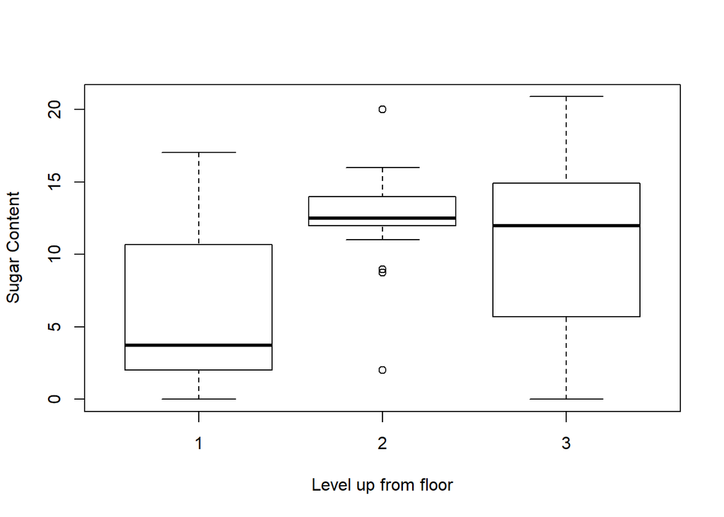

```r
boxplot(UScereal$sugars[UScereal$shelf==1],
        UScereal$sugars[UScereal$shelf==2],
        UScereal$sugars[UScereal$shelf==3],
        names = c(1, 2, 3), xlab="Level up from floor", ylab="Sugar Content")
```

It is clear to see from this data that sugary cereals are stacked primarily on level two and three, while the boring cereals are put on the bottom. Most children will see level two or three at eye level, and will thus be more likely to pick those cereals.